# ST558-651 Homework 7 Part 1

James Carr

6/3/2021

# Horseshoe Crabs

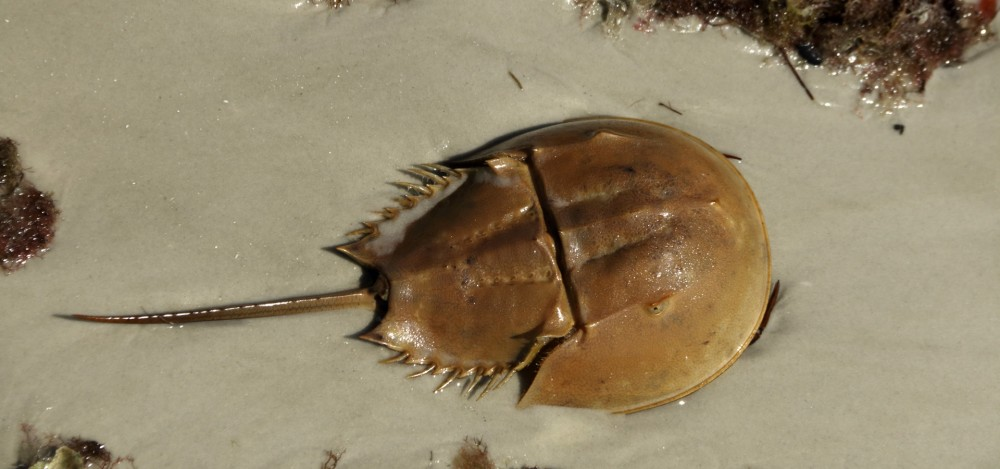

## Introduction

“Horseshoe crabs arrive on the beach in pairs and spawn … during … high tides. Unattached males also come to the beach, crowd around the nesting couples and compete with attached males for fertilizations. Satellite males form large groups around some couples while ignoring others, resulting in a nonrandom distribution that cannot be explained by local environmental conditions or habitat selection.” (Brockmann, H. J. (1996) Satellite Male Groups in Horseshoe Crabs, Limulus polyphemus, Ethology, 102, 1–21. )

### Data

We have a data set about 173 mating female crabs. Data collected included whether or not a male satellite was present (and how many if present) and the color, spine condition, weight, and carapace width of the femal crab.

|  | Color | Spine Condition | Carapace Width | Satellites Present | Weight | Satellite Indicator |
| --- | --- | --- | --- | --- | --- | --- |
| 1 | medium | Both Worn/Broken | 28.3 | 8 | 3050 | At least 1 Satellite |
| 2 | dark | Both Worn/Broken | 22.5 | 0 | 1550 | No Satellite |
| 3 | light | Both Good | 26 | 9 | 2300 | At least 1 Satellite |
| 4 | dark | Both Worn/Broken | 24.8 | 0 | 2100 | No Satellite |
| 5 | dark | Both Worn/Broken | 26 | 4 | 2600 | At least 1 Satellite |
| 6 | medium | Both Worn/Broken | 23.8 | 0 | 2100 | No Satellite |
| 7 | light | Both Good | 26.5 | 0 | 2350 | No Satellite |
| 8 | dark | One Worn/Broken | 24.7 | 0 | 1900 | No Satellite |
| 9 | medium | Both Good | 23.7 | 0 | 1950 | No Satellite |
| 10 | dark | Both Worn/Broken | 25.6 | 0 | 2150 | No Satellite |

[output cut: 163 more lines]

## Numeric Summaries

We’ll consider three categorical variables from the data set: female color, spine condition, and whether or not a satellite was present.

### Full Table

First, it’s quite apparently that most horseshoe crabs have damage to both spines. Also, most horseshoe crabs are ‘medium’ in color. It looks like lighter color crabs may also have taken less damage to their spines.

Color and Spine condition information

|  | Both Good | One Worn/Broken | Both Worn/Broken |
| --- | --- | --- | --- |
| light | 9 | 2 | 1 |
| medium | 24 | 8 | 63 |
| dark | 3 | 4 | 37 |
| darker | 1 | 1 | 20 |

### Table by Satellite Indicator

It could be possible that females with no satellite take have less damage as well, but I am not confident of that. One thing is for sure, females tend to have at least one satellite.

For female crabs with no satellite:

|  | Both Good | One Worn/Broken | Both Worn/Broken |
| --- | --- | --- | --- |
| light | 2 | 0 | 1 |
| medium | 8 | 5 | 13 |
| dark | 0 | 2 | 16 |
| darker | 1 | 1 | 13 |

For female crabs with at least 1 satellite:

|  | Both Good | One Worn/Broken | Both Worn/Broken |
| --- | --- | --- | --- |
| light | 7 | 2 | 0 |
| medium | 16 | 3 | 50 |
| dark | 3 | 2 | 21 |
| darker | 0 | 0 | 7 |

## Visuals

### One Variable

The histograms seem to confirm the most basic of the observations above. Namely that:

- Female crabs tend to be medium in color, and very few light.
- Female crabs also have damage to both spines.
- Most female crabs have at least one satellite.

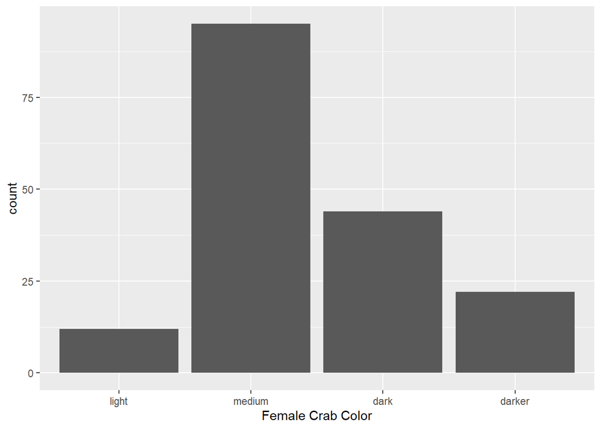

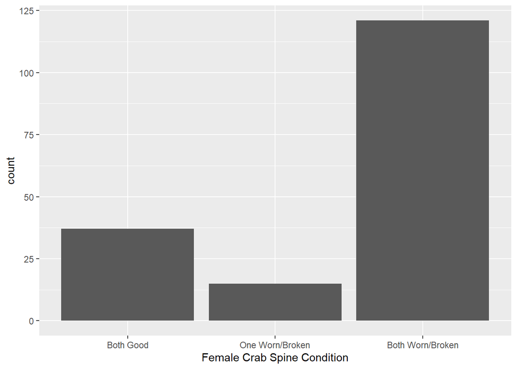

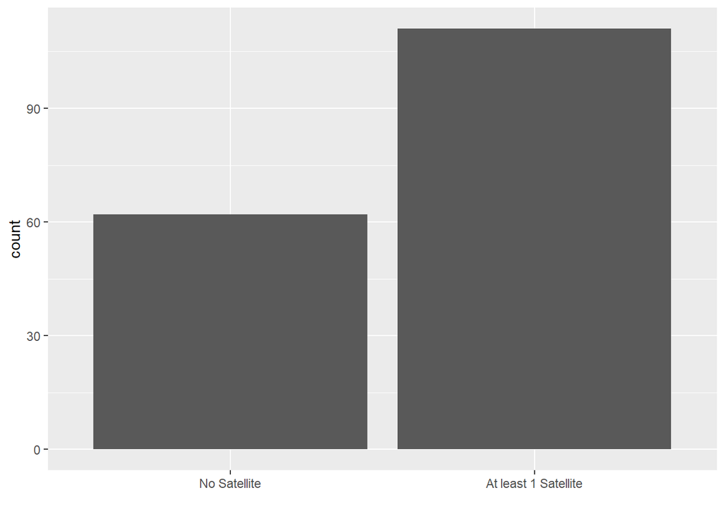

### Two Variables

In the first graph, it seems we can infer that medium and light color tend to have more satellites around. I do not see much in the second graph that seems useful. However, the last graph, our idea of darker colors indicating possibly injury to spines seems to stick out again.

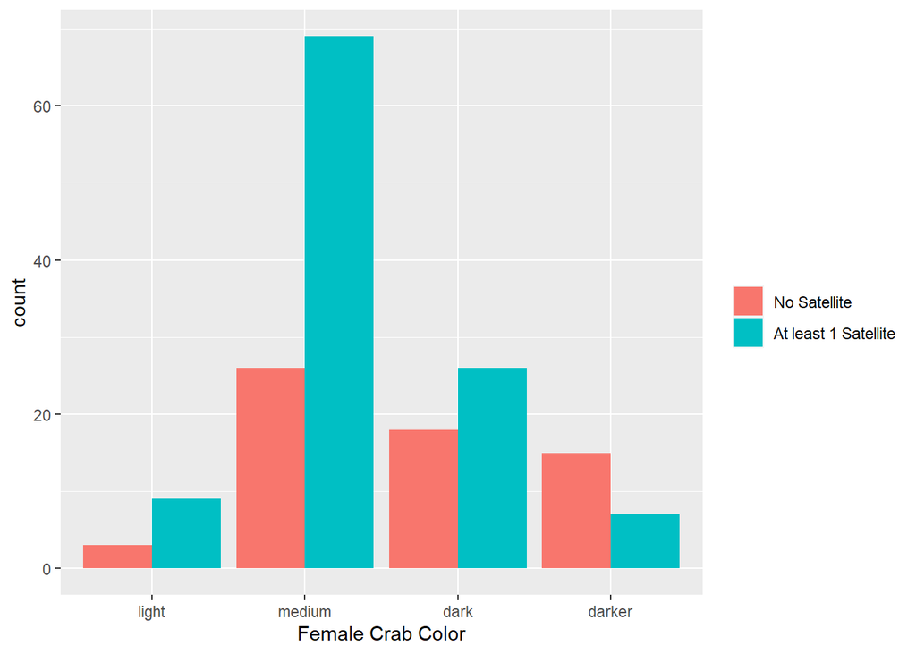

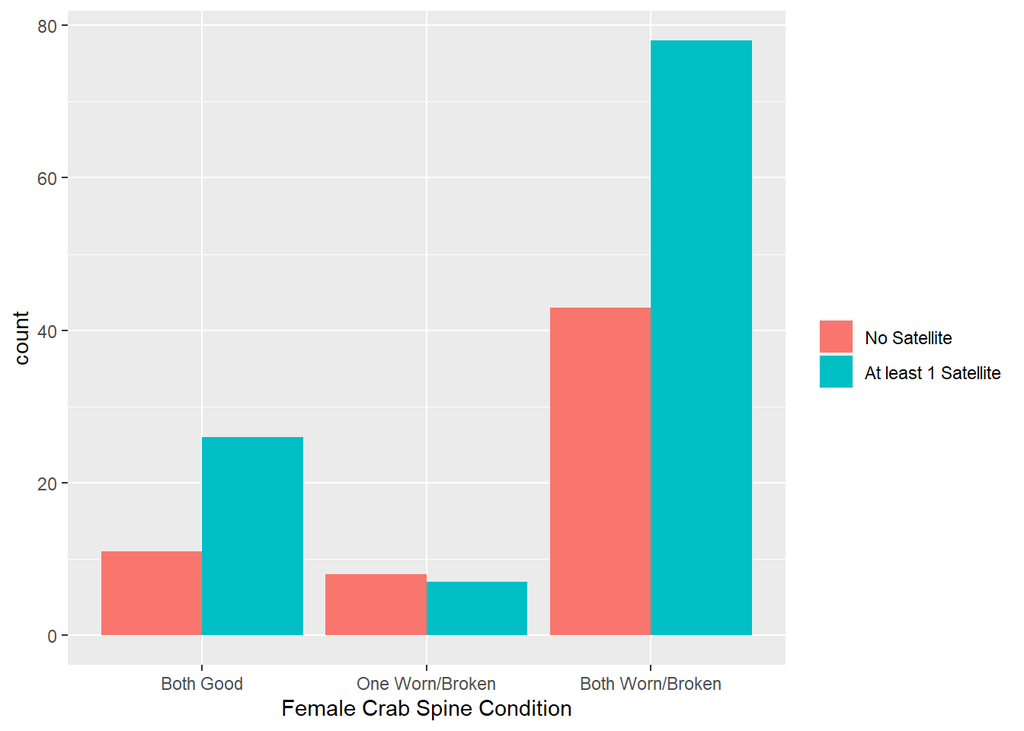

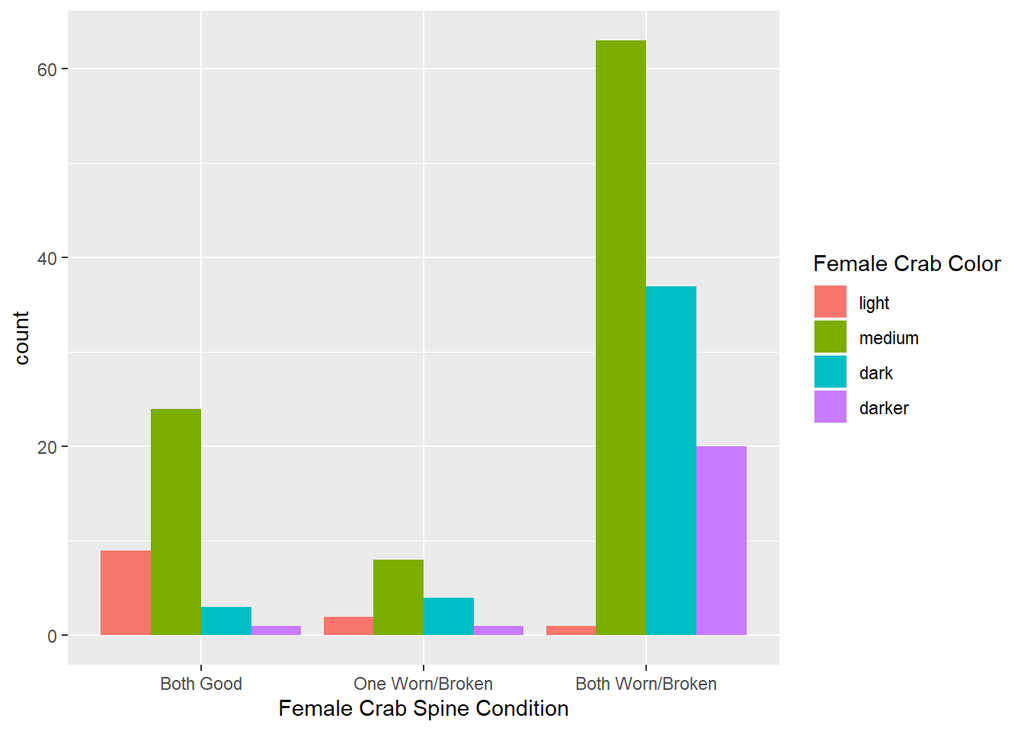

### Three Variables

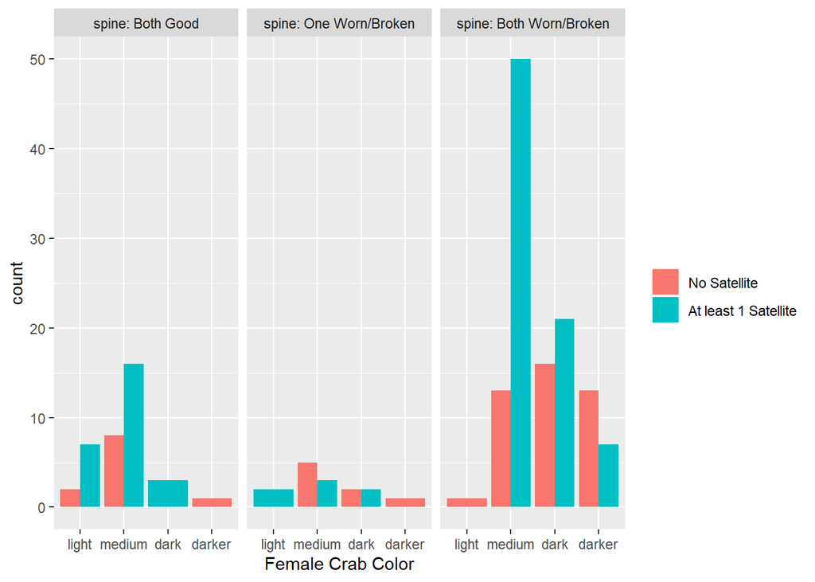